# 3-2-2 QA

Emma Wood

27/09/2021

**Run date and time: 2022-04-28 18:00:52**

## Introduction

3-2-2 is a relatively straightforward indicator but there are a lot of potential disaggregations so it has been automated to speed up the process.

This file runs some basic checks and gives information about the update.

## Potential errors

### Year

Year is taken from the information above the headings in the source spreadsheet. If the cell containing the year contains a superscript straight after the year, year may not be picked up.

Year was identified in all tabs

### Blank values

Blank values due to suppression have been retained in the output csv as this seems to be in line with SDMX options. This is most often the case in cross-disaggregtaions for more extreme groups. For example very low birthweights, and the oldest and youngest age groups.

This table shows rows for which we would definitely expect to have a value but don’t (where it is not a cross-disaggregation, birthweight is not “unlinked deaths” and neither age nor birthweight are “not stated”). If this table contains unexpected disaggregations, check whether the value is present in the original data.

| Year | Neonatal period | Age | Birthweight | Country | Region | Country of birth | Ethnic group | Sex | GeoCode | Units | Unit multiplier | Observation status | Value |
| --- | --- | --- | --- | --- | --- | --- | --- | --- | --- | --- | --- | --- | --- |
| 2020 | Early neonatal |  |  | England and Wales |  | Born in Antarctica and Oceania |  |  |  | Rate per 1,000 live births | Units | Missing value; suppressed |  |
| 2020 | Late neonatal |  |  | England and Wales |  | Born in Antarctica and Oceania |  |  |  | Rate per 1,000 live births | Units | Missing value; suppressed |  |

| Year | Neonatal period | Age | Birthweight | Country | Region | Country of birth | Ethnic group | Sex | GeoCode | Units | Unit multiplier | Observation status | Value |
| --- | --- | --- | --- | --- | --- | --- | --- | --- | --- | --- | --- | --- | --- |
| 2020 |  |  |  | England and Wales |  | Born in Antarctica and Oceania |  |  |  | Rate per 1,000 live births | Units | Missing value; suppressed |  |
| 2020 |  |  |  | England and Wales |  | Other/Not stated |  |  |  | Rate per 1,000 live births | Units | Missing value; suppressed |  |
| 2020 | Early neonatal |  |  | England and Wales |  | Born in Antarctica and Oceania |  |  |  | Rate per 1,000 live births | Units | Missing value; suppressed |  |
| 2020 | Early neonatal |  |  | England and Wales |  | Other/Not stated |  |  |  | Rate per 1,000 live births | Units | Missing value; suppressed |  |
| 2020 | Late neonatal |  | Not stated | England and Wales |  |  |  |  |  | Rate per 1,000 live births | Units | Missing value; suppressed |  |
| 2020 | Late neonatal | Not stated |  | England and Wales |  |  |  |  |  | Rate per 1,000 live births | Units | Missing value; suppressed |  |
| 2020 | Late neonatal |  |  | England and Wales |  | Born in Antarctica and Oceania |  |  |  | Rate per 1,000 live births | Units | Missing value; suppressed |  |
| 2020 | Late neonatal |  |  | England and Wales |  | Other/Not stated |  |  |  | Rate per 1,000 live births | Units | Missing value; suppressed |  |

### Calculations

For birthweight and mother age, and for country of mother’s birth, number of late neonatal deaths are calculated as ’number of neonatal deaths - number of early neonatal deaths.

The rates for early and late neonatal deaths per 1,000 live births are then calculated as ‘number of early [or late] neonatal deaths / (number of live births/1,000)’, where the numerator is greater than or equal to 3.

As a preliminary check, the same calculation is run for all neonatal deaths and this is compared to the published rate for all neonatal deaths. If these two match, we can be confident the functions used to calculate rate are working as they should. If all or most do not match, this indicates a problem that needs to be investigated.

N.B. there may be occasional mismatches due to differences in rounding. The `round()` function rounds .5 to the even number, as always rounding up (as Excel does) leads to accumulation of error when errors are averaged).

See tables below for mismatches:

```
## [1] "there are no mismatches for birthweight and age of mother"
```

```
## [1] "there are no mismatches for mother's country of birth"
```

Further to this, the rates of early and late neonatal deaths should sum to the rate of all neonatal death (which is in the publication). The table below shows rows where the sum of the early and late neonatal rates is different to the published neonatal rate by 0.1 or more, ordered by largest difference:

| Year | Age | Birthweight | Country | Region | Country of birth | Ethnic group | Sex | GeoCode | Units | Unit multiplier | Observation status | Neonatal | Early neonatal | Late neonatal | sum_early_late | difference |
| --- | --- | --- | --- | --- | --- | --- | --- | --- | --- | --- | --- | --- | --- | --- | --- | --- |
| 2020 |  |  | England and Wales |  | Born in UK‚ Isle of Man and Channel Islands |  |  |  | Rate per 1,000 live births | Units | Normal value | 2.3 | 1.8 | 0.6 | 2.4 | 0.1 |
| 2020 |  |  |  |  |  |  | Female | K02000001 | Rate per 1,000 live births | Units | Normal value | 2.4 | 1.9 | 0.6 | 2.5 | 0.1 |

For most disaggregations late neonatal rate (where the count of late neonatal deaths is 3 or greater) is calculated as:  
(number of neonatal deaths - number of early neonatal deaths) /  
(number of live births / 1000)  
However, where country of occurrence is Northern Ireland, the rate for late neonatal deaths is calculated as ‘neonatal death rate - early neonatal death rate’ (where the count of late neonatal deaths is 3 or greater). the number of live births *doesn’t* include non-residents, but the number of deaths *does* include non-residents. The published rates use number of live births including non-residents so that the numerator and denominator are comparable.  
The reason I haven’t used this simpler calculation for all disaggregations is twofold:  
1. The former calculation is more precise because of rounding in the rates  
2. Early neonatal death rate is not available for birthweight by age of mother

## Plots

Plots of the data are shown below. If you see anything unexpected in the plots, please manually check the data are correct, and edit the code if necessary.

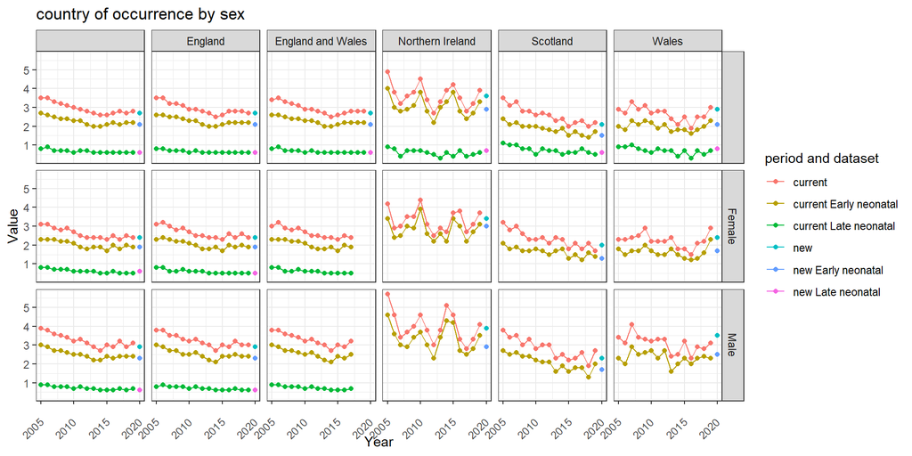

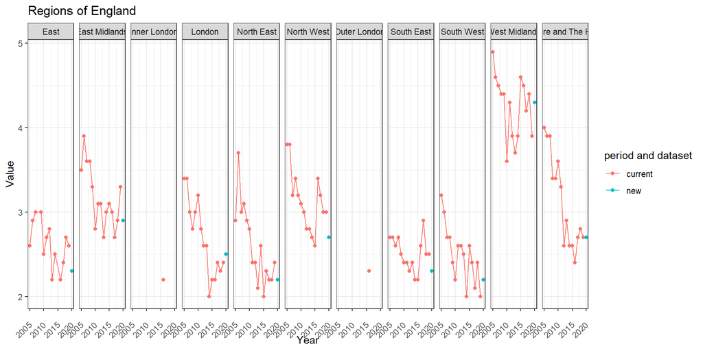

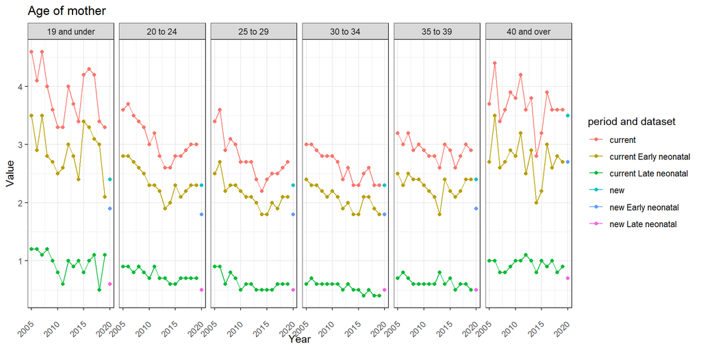

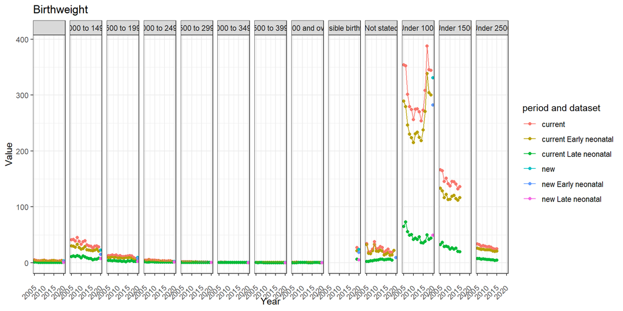

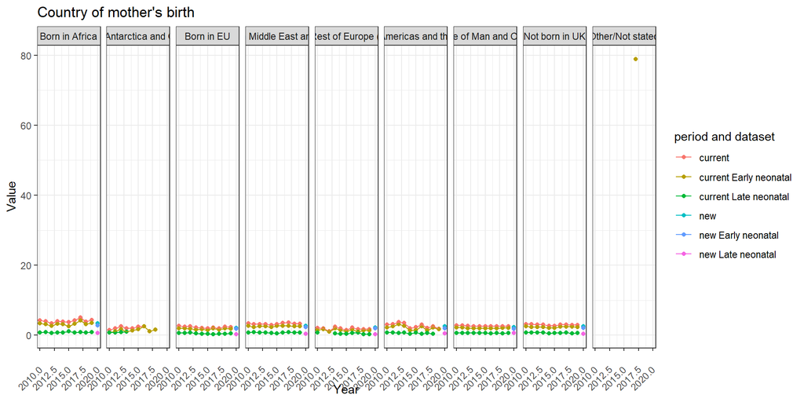

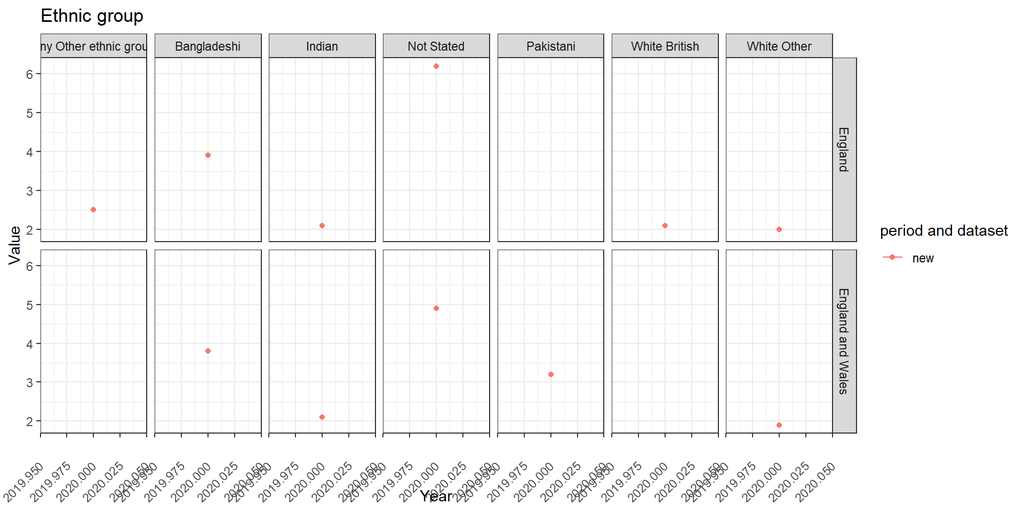